# PML Course Assignment

A H

Saturday, January 30, 2016

# Objective

The objective of this report is to develop a classifier of weightlifting form based on body sensor measurements, and test the accuracy of the classifier on a hold-out test set.

# Experiment

The data for this project come from the Weight Lifting Exercise Dataset here: http://groupware.les.inf.puc-rio.br/har#weight_lifting_exercises#ixzz3yl3Oja5v.

To summarize, six males aged 20-28 were asked to perform one set of 10 repetitions of the Unilateral Dumbbell Biceps Curl (with 1.25 kg weight) in five different fashions:

- exactly according to the specification (Class A)
- throwing the elbows to the front (Class B)
- lifting the dumbbell only halfway (Class C)
- lowering the dumbbell only halfway (Class D)
- throwing the hips to the front (Class E).

Class A is the specified (correct) fashion, and classes {B,C,D,E} are incorrect methods. During the excercise, subjects wore on-body sensors (arm, forearm, belt, and on dumbell). We seek to predict the Class given information about the subjects, time of experiment, and the kinetic measurements from the on-body sensors.

A confusion matrix diagrammed at the URL referenced above shows the study authors have achieved roughly 78.2% leave-one-out-cross-validation (LOOCV) accuracy on the dataset using a bagged Random Forest.

# Dataset

The dataset contains 19622 training cases and 20 test cases, on 159 variables, derived from 6 subjects. The number of classes to predict is 5.

To get a sense of the data, we display a small interval of values fro the gyroscopic forearm sensor X-coordinate, from subject **jeremy** during a bout of curls:

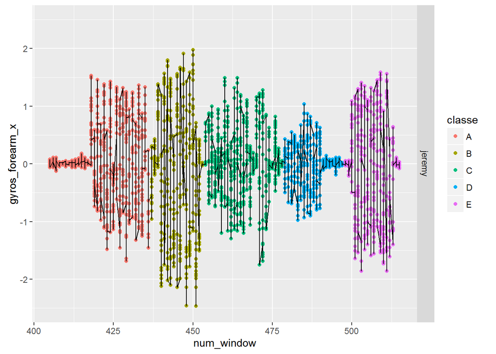

```r
sp <- ggplot( subset(training, user_name=="jeremy"), aes(x=num_window, y=gyros_forearm_x)) + geom_point(shape=19, aes(color=classe)) + geom_line() + facet_grid(user_name ~ .) + ylim(-2.5,2.5) + xlim(405,515)
sp
```

We see the examples of each of the training classes A-E. X-coordinate excursions are largest in class B (throwing the elbow out), and they are reduced especially during class D (lowing the dumbell only half way). This makes intuitive sense.

# Model building and cross validation

Given the nature of the activity, we expect there may be large differences in the profiles between the 6 subjects. In addition, with the large number of predictors, we expect many predictors to be correlated. Therefore, we use principal components to reduce the space of predictors, and we fit a separate random forest model for each subject in the dataset.

```r
preProcessFeatures <- function(training) {
  j.sk <- grepl("^(skewness|kurtosis|max_yaw|amplitude_yaw|min_yaw)", names(training))
  j.sparse <- apply(training, 2, function (z) sum(is.na(z)))>nrow(training)*0.90
  training.vfilt <- training[,!j.sk & !j.sparse,]
  training.vfilt <- training.vfilt[, 8:(ncol(training.vfilt)-1)]
  training.vfilt.mat <- data.matrix(training.vfilt)
}

pmodel <- function(training.vfilt.mat) {
  pp <- prcomp(training.vfilt.mat, center=TRUE, scale.=TRUE)
}

apply.pmod <- function(training.vfilt.mat, pmod, npp=10) {
    predict(pmod, newdata=training.vfilt.mat)[,1:npp]
}

make.pred.frame <- function(training, tvmp) {
    training.pp <- data.frame(classe=training$classe,
                          tvmp)
}
```

```r
# train
tvm <- preProcessFeatures(training)
pmod <- pmodel(tvm)
tvmp <- apply.pmod(tvm, pmod)
pf <- make.pred.frame(training, tvmp)
pfl <- split(pf, training$user_name)
mod.rf <- list()
set.seed(14173)
for (user in levels(training$user_name)) {
  mod.rf[[user]] <- train( classe ~ ., data=pfl[[user]],
                           method="rf",
                           trainControl=trainControl("cv", number=10))
}
```

The amount of variance explained the the PCAs is as follows:

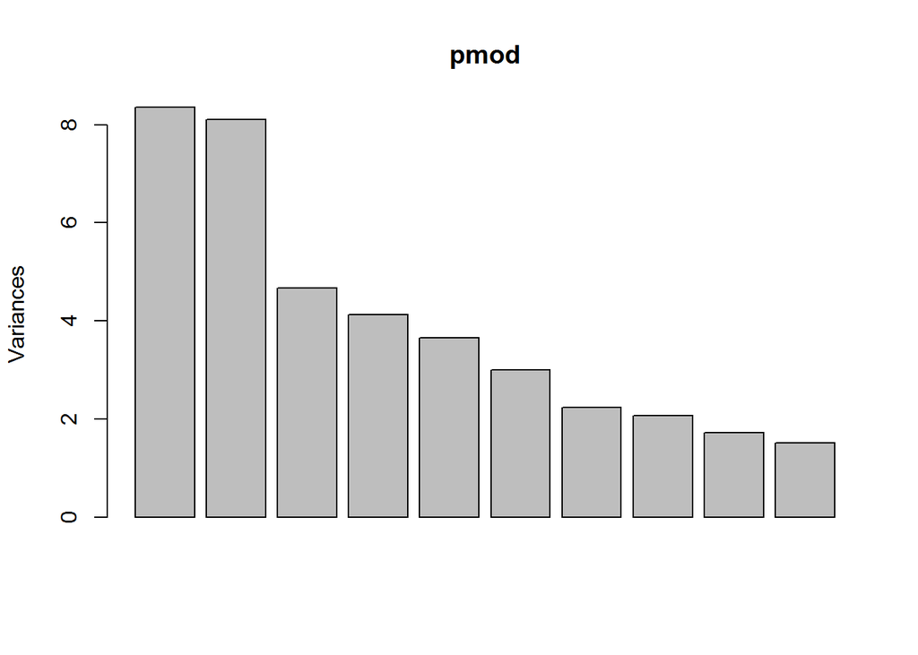

```r
plot(pmod)
```

Thus, we estimate 10 PCs contain most of the variance in the data. Plotting the training observations on the first 2 PCAs we see that the subject is the major driver of the first 2 PCAs, as expected.

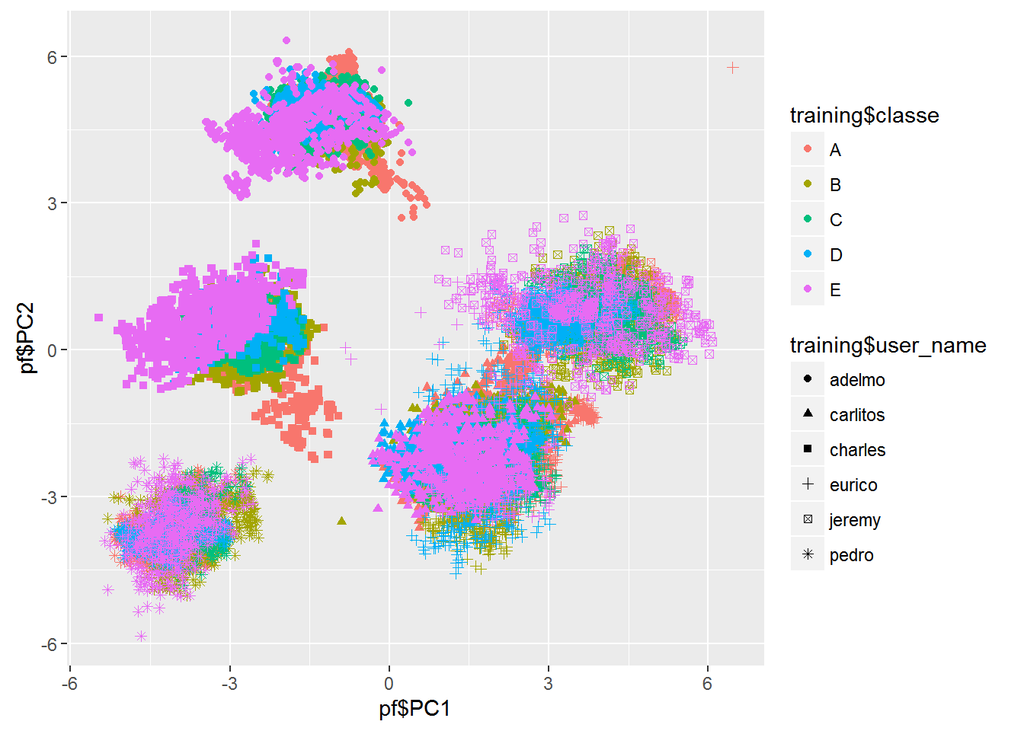

```r
sp <- ggplot(NULL, aes(x=pf$PC1, y=pf$PC2)) +
  geom_point(aes(color=training$classe, shape=training$user_name))
sp
```

# Expected out of sample error

The expected out of sample error is given by the caret train() function output, estimated by resampling in the training set:

```r
# Accuracy per-subject
accuracy <- sapply(mod.rf, function(z) z$results$Accuracy[1])
# Overall accuracy
accuracy.overall <- sum(accuracy * sapply(pfl, nrow)) / sum(sapply(pfl,nrow))
```

Thus we estimate the accuracy in the hold-out set will be 0.95.

The predictions on the test set are as follows:

```r
# test
tvm.t <- preProcessFeatures(testing)
tvmp.t <- apply.pmod(tvm.t, pmod)
preds <- factor(levels=levels(training$classe))
for (user in levels(testing$user_name)) {
  itt <- which(testing$user_name==user)
  preds[itt] <- predict(mod.rf[[user]], newdata=data.frame(tvmp.t[itt,,drop=FALSE]))
}
```

```r
kable(data.frame(test.case=1:nrow(testing), predicted.class=preds))
```

| test.case | predicted.class |
| --- | --- |
| 1 | B |
| 2 | A |
| 3 | B |
| 4 | A |
| 5 | A |
| 6 | E |
| 7 | D |
| 8 | B |
| 9 | A |
| 10 | A |
| 11 | B |
| 12 | C |
| 13 | B |
| 14 | A |
| 15 | E |
| 16 | E |
| 17 | A |
| 18 | B |
| 19 | B |
| 20 | B |

# Conclusions

A model was built on the weighlifting dataset. PCA was used to reduce the space of predictors, and subject-specific random forest models were used to control for between-subject variation in motions. Resampling on the training set estimated the overall accuracy for out-of-sample data to be 0.95. Predictions on the test set were made.